# Klasyfikacja

- Pokaż cały kod
- Ukryj cały kod
- Pokaż źródło

Autor

Sebastian

Utworzono

24 sierpnia 2026

### 1. Załaduj wszystkie pakiety, z których będziesz korzystać

**Kod**

```r
library(tidymodels)
library(tidyverse)
library(modeldata)
library(vip)
```

### 2. Klasyfikacja

> Do tej analizy będziesz potrzebować zbioru danych `credit_data` z pakietu `modeldata`. Zapoznaj się z tym zbiorem, wyświetl tabelkę. Czy w zbiorze występują braki danych?

**Kod**

```r
credit_data
```

| Status | Seniority | Home | Time | Age | Marital | Records | Job | Expenses | Income | Assets | Debt | Amount | Price |
| --- | --- | --- | --- | --- | --- | --- | --- | --- | --- | --- | --- | --- | --- |
| good | 9 | rent | 60 | 30 | married | no | freelance | 73 | 129 | 0 | 0 | 800 | 846 |
| good | 17 | rent | 60 | 58 | widow | no | fixed | 48 | 131 | 0 | 0 | 1000 | 1658 |
| bad | 10 | owner | 36 | 46 | married | yes | freelance | 90 | 200 | 3000 | 0 | 2000 | 2985 |
| good | 0 | rent | 60 | 24 | single | no | fixed | 63 | 182 | 2500 | 0 | 900 | 1325 |
| good | 0 | rent | 36 | 26 | single | no | fixed | 46 | 107 | 0 | 0 | 310 | 910 |
| good | 1 | owner | 60 | 36 | married | no | fixed | 75 | 214 | 3500 | 0 | 650 | 1645 |
| good | 29 | owner | 60 | 44 | married | no | fixed | 75 | 125 | 10000 | 0 | 1600 | 1800 |
| good | 9 | parents | 12 | 27 | single | no | fixed | 35 | 80 | 0 | 0 | 200 | 1093 |
| good | 0 | owner | 60 | 32 | married | no | freelance | 90 | 107 | 15000 | 0 | 1200 | 1957 |
| bad | 0 | parents | 48 | 41 | married | no | partime | 90 | 80 | 0 | 0 | 1200 | 1468 |

[output cut: 4444 more lines]

**Kod**

```r
sum(is.na(credit_data))
```

```
[1] 455
```

- **Twoja odpowiedź: Istnieją i jest ich 455**

##### Jakie etykiety występują w zmiennej `Status` i jakie są ich liczebności? (To będzie zmienna, którą będziemy przewidywać.)

**Kod**

```r
credit_data %>% count(Status)
```

| Status | n |
| --- | --- |
| bad | 1254 |
| good | 3200 |

##### Podziel dane na zbiór treningowy i testowy (70/30, z zachowaniem proporcji zmiennej przewidywanej) (ziarno losowania - numer Twojego indeksu)

**Kod**

```r
set.seed(345777)

credit_split <- initial_split(credit_data, prop = 0.7, strata = Status)
credit_train <- training(credit_split)
credit_test <- testing(credit_split)
```

#### Modele

##### Twoje zadanie polega na porównaniu kilku modeli klasyfikacyjnych z użyciem pakietu `tidymodels` (za jednych zamachem) i odpowiedzi na kilka pytań:

- rozważ trzy różne “przepisy” (przygotuj dane do modelowania na 3 różne sposoby, wybór zmiennych i ich przygotowanie - według Twojego uznania)

**Kod**

```r
# Edytuj

rec_0 <- recipe(Status ~ ., data = credit_train)

rec_1 <- rec_0 %>%
  step_impute_mode(Home, Marital)

rec_2 <- rec_1 %>%
  step_normalize(all_numeric_predictors())
```

- rozważ modele: Random Forest (parametry domyślne, silnik: `ranger`), regresja logistyczna. Nazwij je odpowiednio: `model_rf` i `model_log`

**Kod**

```r
model_rf <- rand_forest() %>%
  set_engine("ranger", importance = 'permutation') %>%
  set_mode("classification")
model_log <- logistic_reg() %>%
  set_engine("glm") %>%
  set_mode("classification")
```

- tym samym do wytrenowania i porównania będziesz mieć 6 modeli (3 przepisy * 2 modele)
- nie buduj modeli osobno - chodzi o to, żeby wytrenować i porównać je jednocześnie
- trening i porównanie wykonaj z użyciem kroswalidacji na zbiorze treningowym

**Kod**

```r
credit_folds <- vfold_cv(credit_train, v = 5, strata = Status)

modele <- workflow_set(
    preproc = list(
      nr0 = rec_0,
      nr1 = rec_1,
      nr2 = rec_2
    ),
    models = list(
      reg_log = model_log,
      drzewo = model_rf
    ),
    cross = TRUE
  )
```

**Kod**

```r
metrics <- modele %>%
  workflow_map(
    "fit_resamples",
    resamples = credit_folds,
    metrics = metric_set(accuracy, roc_auc, sensitivity, specificity),
    verbose = TRUE
  ) %>%
  collect_metrics()
```

- wyświetl tabelkę przedstawiającą wszystkie modele z wartościami metryk: dokładność, pole pod krzywą ROC, czułość i swoistość (upewnij się, że czułość i swoistość oznaczają to, co trzeba - ważniejsze jest dla nas wychwycenie osób, które nie powinny dostać kredytu)

**Kod**

```r
metrics
```

| wflow_id | .config | preproc | model | .metric | .estimator | mean | n | std_err |
| --- | --- | --- | --- | --- | --- | --- | --- | --- |
| nr0_reg_log | pre0_mod0_post0 | recipe | logistic_reg | accuracy | binary | 0.8076757 | 5 | 0.005198929 |
| nr0_reg_log | pre0_mod0_post0 | recipe | logistic_reg | roc_auc | binary | 0.8311238 | 5 | 0.012404488 |
| nr0_reg_log | pre0_mod0_post0 | recipe | logistic_reg | sensitivity | binary | 0.4627385 | 5 | 0.025415880 |
| nr0_reg_log | pre0_mod0_post0 | recipe | logistic_reg | specificity | binary | 0.9247520 | 5 | 0.007519700 |
| nr0_drzewo | pre0_mod0_post0 | recipe | rand_forest | accuracy | binary | 0.7863363 | 5 | 0.008329895 |
| nr0_drzewo | pre0_mod0_post0 | recipe | rand_forest | roc_auc | binary | 0.8359016 | 5 | 0.007746285 |
| nr0_drzewo | pre0_mod0_post0 | recipe | rand_forest | sensitivity | binary | 0.4710130 | 5 | 0.028218196 |
| nr0_drzewo | pre0_mod0_post0 | recipe | rand_forest | specificity | binary | 0.9098214 | 5 | 0.008066657 |
| nr1_reg_log | pre0_mod0_post0 | recipe | logistic_reg | accuracy | binary | 0.8077446 | 5 | 0.005193996 |
| nr1_reg_log | pre0_mod0_post0 | recipe | logistic_reg | roc_auc | binary | 0.8310792 | 5 | 0.012409887 |

[output cut: 14 more lines]

- **Twoja odpowiedź:**
- Który model okazał się najlepszy pod względem dokładności? Czy pole pod krzywą ROC też wskazuje na ten model? Jak oceniasz czułość i swoistość dla tego modelu? (pamiętaj, że lasy losowe są losowe:) Zadbaj o to, żeby wynik był stabilny)

**Kod**

```r
metrics %>% filter(.metric == 'accuracy') %>% arrange(desc(mean))
```

| wflow_id | .config | preproc | model | .metric | .estimator | mean | n | std_err |
| --- | --- | --- | --- | --- | --- | --- | --- | --- |
| nr1_reg_log | pre0_mod0_post0 | recipe | logistic_reg | accuracy | binary | 0.8077446 | 5 | 0.005193996 |
| nr2_reg_log | pre0_mod0_post0 | recipe | logistic_reg | accuracy | binary | 0.8077446 | 5 | 0.005193996 |
| nr0_reg_log | pre0_mod0_post0 | recipe | logistic_reg | accuracy | binary | 0.8076757 | 5 | 0.005198929 |
| nr2_drzewo | pre0_mod0_post0 | recipe | rand_forest | accuracy | binary | 0.7876199 | 5 | 0.007656316 |
| nr1_drzewo | pre0_mod0_post0 | recipe | rand_forest | accuracy | binary | 0.7872999 | 5 | 0.007254004 |
| nr0_drzewo | pre0_mod0_post0 | recipe | rand_forest | accuracy | binary | 0.7863363 | 5 | 0.008329895 |

**Kod**

```r
metrics %>% filter(.metric == 'roc_auc') %>% arrange(desc(mean))
```

| wflow_id | .config | preproc | model | .metric | .estimator | mean | n | std_err |
| --- | --- | --- | --- | --- | --- | --- | --- | --- |
| nr2_drzewo | pre0_mod0_post0 | recipe | rand_forest | roc_auc | binary | 0.8365461 | 5 | 0.007859688 |
| nr1_drzewo | pre0_mod0_post0 | recipe | rand_forest | roc_auc | binary | 0.8365434 | 5 | 0.007932234 |
| nr0_drzewo | pre0_mod0_post0 | recipe | rand_forest | roc_auc | binary | 0.8359016 | 5 | 0.007746285 |
| nr0_reg_log | pre0_mod0_post0 | recipe | logistic_reg | roc_auc | binary | 0.8311238 | 5 | 0.012404488 |
| nr1_reg_log | pre0_mod0_post0 | recipe | logistic_reg | roc_auc | binary | 0.8310792 | 5 | 0.012409887 |
| nr2_reg_log | pre0_mod0_post0 | recipe | logistic_reg | roc_auc | binary | 0.8310792 | 5 | 0.012409887 |

**Kod**

```r
metrics %>% filter(wflow_id == "nr1_reg_log")
```

| wflow_id | .config | preproc | model | .metric | .estimator | mean | n | std_err |
| --- | --- | --- | --- | --- | --- | --- | --- | --- |
| nr1_reg_log | pre0_mod0_post0 | recipe | logistic_reg | accuracy | binary | 0.8077446 | 5 | 0.005193996 |
| nr1_reg_log | pre0_mod0_post0 | recipe | logistic_reg | roc_auc | binary | 0.8310792 | 5 | 0.012409887 |
| nr1_reg_log | pre0_mod0_post0 | recipe | logistic_reg | sensitivity | binary | 0.4627385 | 5 | 0.025415880 |
| nr1_reg_log | pre0_mod0_post0 | recipe | logistic_reg | specificity | binary | 0.9247804 | 5 | 0.007534458 |

**Kod**

```r
metrics %>% filter(wflow_id == "nr2_drzewo")
```

| wflow_id | .config | preproc | model | .metric | .estimator | mean | n | std_err |
| --- | --- | --- | --- | --- | --- | --- | --- | --- |
| nr2_drzewo | pre0_mod0_post0 | recipe | rand_forest | accuracy | binary | 0.7876199 | 5 | 0.007656316 |
| nr2_drzewo | pre0_mod0_post0 | recipe | rand_forest | roc_auc | binary | 0.8365461 | 5 | 0.007859688 |
| nr2_drzewo | pre0_mod0_post0 | recipe | rand_forest | sensitivity | binary | 0.4721688 | 5 | 0.025160604 |
| nr2_drzewo | pre0_mod0_post0 | recipe | rand_forest | specificity | binary | 0.9111607 | 5 | 0.009506937 |

- **Twoja odpowiedź:** Najlepszy pod względem dokładności jest model `nr1_reg_log`. Pod względem auc to jest to model `nr2_drzewo`. Oba mają wysoką swoistość i niską czułość
- wyznacz macierz pomyłek, dokładność i pole pod krzywą ROC dla najlepszego modelu na zbiorze testowym

**Kod**

```r
wk_fit_log <- workflow() %>%
  add_recipe(rec_1) %>%
  add_model(model_log) %>%
  fit(data = credit_train)

credit_pred <- credit_test %>%
  select(Status) %>%
  mutate(predict(wk_fit_log, new_data = credit_test))

credit_pred %>%
  conf_mat(truth = Status, estimate = .pred_class)
```

```
          Truth
Prediction bad good
      bad  136   61
      good 176  842
```

**Kod**

```r
credit_pred %>%
  yardstick::accuracy(truth = Status, estimate = .pred_class)
```

| .metric | .estimator | .estimate |
| --- | --- | --- |
| accuracy | binary | 0.8049383 |

**Kod**

```r
credit_pred_1 <- credit_pred %>%
  mutate(Status = factor(Status, levels = c("good", "bad")))
credit_pred_1 <- augment(wk_fit_log, new_data = credit_test)

credit_pred_1 %>% roc_auc(truth = Status, .pred_bad)
```

| .metric | .estimator | .estimate |
| --- | --- | --- |
| roc_auc | binary | 0.8309517 |

- rozważ najlepszy spośród modeli Random Forest i najlepszy spośród modeli regresji logistycznej. Czy oba modele wskazują na te same zmienne, jako zmienne najbardziej wpływowe w procesie klasyfikacji? Które ze zmiennych zostały uznane za najważniejsze przez dany model. Wykonaj wykresy informujące o ważności zmiennych dla poszczególnych modeli. Czy oba modele “widzą” to tak samo? (przydatne funkcje: `extract_...`, `vip`)

**Kod**

```r
wk_fit_drzewo <- workflow() %>%
  add_model(model_rf) %>%
  add_recipe(rec_2) %>%
  fit(data = credit_train)
```

**Kod**

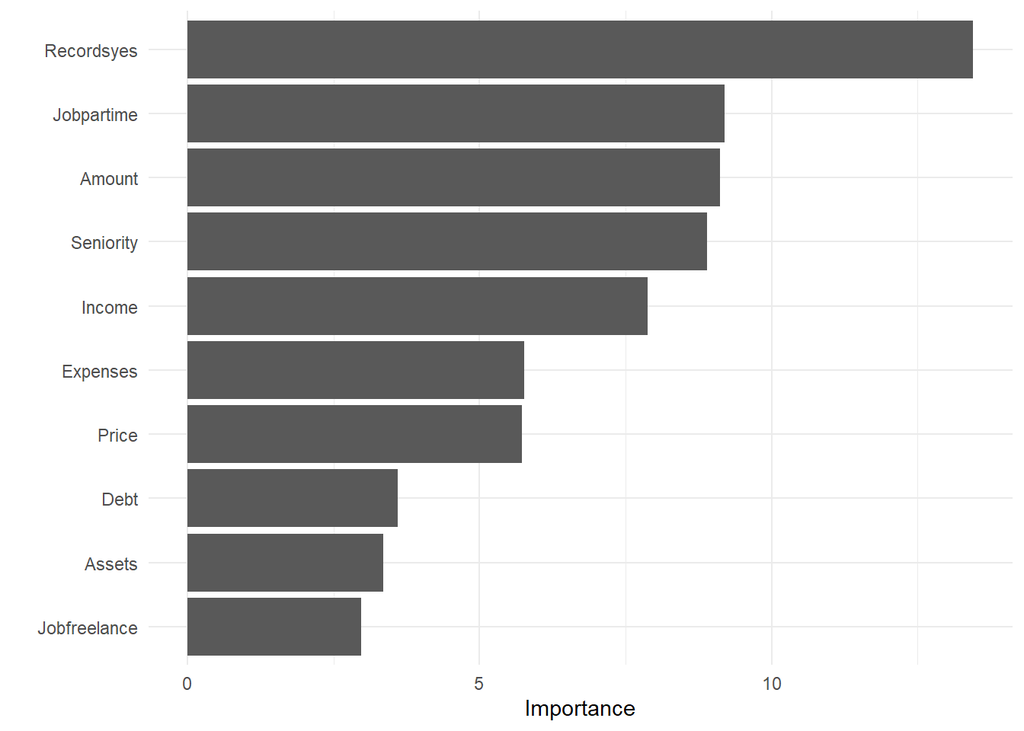

```r
vip(wk_fit_log %>%
      extract_fit_engine()) +
  theme_minimal()
```

**Kod**

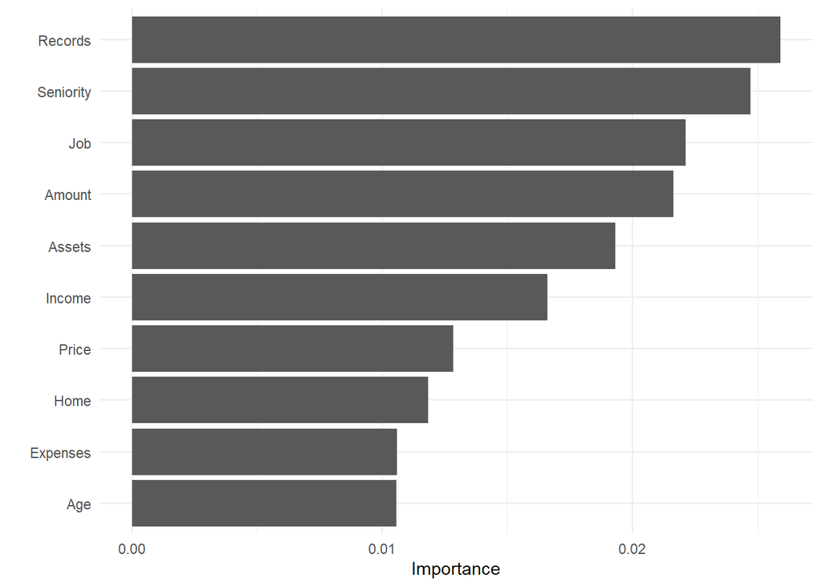

```r
vip(wk_fit_drzewo %>%
      extract_fit_engine()) +
  theme_minimal()
```

- **Twoja odpowiedź: Oba modele wskazują na te samą zmienna, jest to zmienna ‘Records’.**